# R Introduction

9 March 2016

## Overview

## Introduction

R is a programming environment focussed on statistical analysis

- Open source (based on S)
- Uses a well defined, but simple programming language
- Many statistical analysis methods build in
- Can be expanded by adding packages
- Well supported by a large community of users
- Generally fast enough

## Base R and packages

R and R packages are availbale for download from the Comprehensive R Archive Network (CRAN)

- cran.r-project.org
  - Some packages available through github
- R comes with a number of basic data management, analysis and visualisation tools
- R's power and flexibility, however, come from the large number of (third-party) packages available from CRAN

## Using R

R by default comes with a command line client that you can use directly. Most users prefer to use a frontend though. Multiple frontends are available

- RStudio
  - *This is the one I use*
- Deducer
- Rattle

Some users prefer to write code in a text editor (like vim/notepad) and load the source files into R.

## RStudio

## Overview

[figure not shown]

## Popular packages

- **ggplot2**: Visualization based on Grammar of Graphics
  - It grows on you
- **reshape2**: Data cleaning. Transforming data from short form to long form (and back)
- **broom**: Standardizing analysis results
- **boot**: Bootstrapping
- **devtools**: Help developing new packages
- **fluEvidenceSynthesis**: Modelling flu epidemics

```r
install.packages("ggplot2")
library(ggplot2)
```

## Data

## Loading of data

R can load data from many sources, such as json, xls(x) and csv. I tend to use csv files (comma separated tables). Loading a excel or csv file results in a `data.frame` that holds the table.

```r
tbl <- read.csv("assets/diamonds.csv",row.names=1)
pander(head(tbl,n=3))
```

| X | carat | cut | color | clarity | depth | table | price | x | y | z |
| --- | --- | --- | --- | --- | --- | --- | --- | --- | --- | --- |
| 1 | 0.23 | Ideal | E | SI2 | 61.5 | 55 | 326 | 3.95 | 3.98 | 2.43 |
| 2 | 0.21 | Premium | E | SI1 | 59.8 | 61 | 326 | 3.89 | 3.84 | 2.31 |
| 3 | 0.23 | Good | E | VS1 | 56.9 | 65 | 327 | 4.05 | 4.07 | 2.31 |

## Visualisation

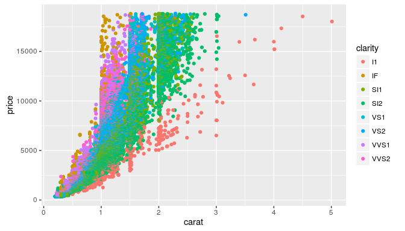

```r
library(ggplot2)
ggplot( data=tbl ) + geom_point(aes(x=carat,y=price,color=clarity))
```

## Data cleanup

80% of data analysis is spent on the process of cleaning and preparing the data (*Dasu and Johnson 2003*)

- Over 85% of all statistics are made up on the spot (*David Mitchell*)

### Short form data

```r
library(reshape2)
pander(flu.data)
```

| id | age | H1N1 | H3N2 |
| --- | --- | --- | --- |
| 1 | 3 | 2 | 3 |
| 2 | 69 | 1 | 0 |

Long form is often easier to parse computationally

### Long form data

```r
pander(melt(flu.data, c("id","age"),
            variable.name="Subtype",
            value.name="Titre"))
```

| id | age | Subtype | Titre |
| --- | --- | --- | --- |
| 1 | 3 | H1N1 | 2 |
| 2 | 69 | H1N1 | 1 |
| 1 | 3 | H3N2 | 3 |
| 2 | 69 | H3N2 | 0 |

## Analysis

## Data summary

```r
pander(summary(diamonds)[1:6,1:5])
```

| carat | cut | color | clarity | depth |
| --- | --- | --- | --- | --- |
| Min. :0.2000 | Fair : 1610 | D: 6775 | SI1 :13065 | Min. :43.00 |
| 1st Qu.:0.4000 | Good : 4906 | E: 9797 | VS2 :12258 | 1st Qu.:61.00 |
| Median :0.7000 | Very Good:12082 | F: 9542 | SI2 : 9194 | Median :61.80 |
| Mean :0.7979 | Premium :13791 | G:11292 | VS1 : 8171 | Mean :61.75 |
| 3rd Qu.:1.0400 | Ideal :21551 | H: 8304 | VVS2 : 5066 | 3rd Qu.:62.50 |
| Max. :5.0100 | NA | I: 5422 | VVS1 : 3655 | Max. :79.00 |

## Generalized linear model

```r
glm.diamonds <- glm( price ~ carat + depth + cut, data=diamonds )
pander(tidy(glm.diamonds))
```

| term | estimate | std.error | statistic | p.value |
| --- | --- | --- | --- | --- |
| (Intercept) | 434.8 | 301.9 | 1.44 | 0.1499 |
| carat | 7873 | 13.97 | 563.7 | 0 |
| depth | -50.42 | 4.848 | -10.4 | 2.601e-25 |
| cut.L | 1148 | 27.52 | 41.73 | 0 |
| cut.Q | -471.6 | 23.75 | -19.86 | 1.952e-87 |
| cut.C | 366.1 | 20.19 | 18.13 | 3.049e-73 |
| cut^4 | 87.58 | 16.27 | 5.382 | 7.382e-08 |

## Write your own function

```r
lab.results <- c("<10", "10", "20", "10", "160", "40")

convert.titre <- function( value )
{
  if (value == "<10")
    return(0)
  v <- as.numeric(value)
  log(v/10)/log(2) + 1
}
pander(sapply( lab.results, convert.titre ))
```

| <10 | 10 | 20 | 10 | 160 | 40 |
| --- | --- | --- | --- | --- | --- |
| 0 | 1 | 2 | 1 | 5 | 3 |

## Maximum likelihood

Data that we assume is normally distributed. \[f_N(y; \mu, \sigma)\]

Likelihood function: \[\begin{aligned} \log &\mathcal{L}(\mu,\sigma; \vec{y})=\\ &\sum_i \log f_N(y_i;\mu,\sigma) \end{aligned}\]

Note: \(\mu\) and \(\sigma\) are model parameters, could be dependent on other variables

```r
nll <- function( pars, data )
{
  -sum( dnorm(data, pars[1],
              pars[2],TRUE) )
}

pander(tidy(
  optim(c(0,1),nll,data=y)
))
```

| parameter | value |
| --- | --- |
| parameter1 | 5.031 |
| parameter2 | 0.1739 |

## Maximum likelihood result

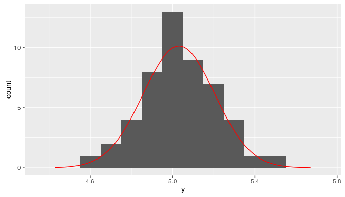

```r
ggplot(data=data.frame(y)) + geom_histogram(aes(x=y),binwidth=bw) +
  geom_line(data=fit.dist,aes(x=x,y=y),colour="red")
```

## Advanced packages

- **fluEvidenceSynthesis**: Applying Evidence Synthesis to flu data
- **pomp**: Stochastic dynamical systems
- **boot**: Bootstrapping
- **mcmc/MCMCpack**: Easy access to MCMC methods

Generally developed in C/C++ for performance reasons, with R bindings that allows one to run the functions

## Further tips

## Source control

Keep all R files in source control (e.g. git)

- Supported by RStudio
- Keep track of changes
- Can go back to previous changes

Note git can be used locally, no need to put things on github

### Caveats

- Binary files (word, xls(x), zip, png and jpg)
  - Committing them is fine if they stay the same
  - Convert xls(x) to csv before saving
  - svg is good for figures
- .gitignore

## R Markdown

### code and documentation in one file

R Markdown is a simple formatting language that enables you to create documents (pdf/word/html) from your R results.

- Very usefull to keep notes about what you are doing
- Equations (TeX)
  - \(f(x) = x \sum_i c_i\)
- Can write whole manuscripts
- Presentations
  - Like this one
- Text file, so excellent for source control

## R Markdown example

[figure not shown]

## Build in help

- **help** (`?function`): Basic help for that function
- **vignette**: Tend to give an overview of the package and its workflow. Normally based around an example taking you through the whole process

```r
?help
```

[interactive chart not shown]

## Bugs and issues

Bugs in core R packages are rare, but more common in less known/used packages.

R is an open source project, support is provided by community members. Don't be afraid to ask questions on the mailing lists.

- r-help@r-project.org

Specific packages often live on github, you can reach them by opening issues. People are often happy that package is used (that's why they put them out there) and happy to help.

- Packages are often developed by people like you and me